# A PRIORI DECIDED PROCEDURE for ‘ruff sperm’ project

Martin Bulla, Wolfgang Forstmeier, Katrin Martin, Kim Teltscher, Tomas Albrecht, Clemens Küpper, David B Lank & Bart Kempenaers

2020-10-28 16:03:38

Code to load tools and prepare data:

```r
  require(here)
  source(here::here('R/tools.R'))

  v = data.table(read_excel(here::here('Data/ruff_sperm_Vancouver_2018.xlsx'), sheet = 1))
  v = v[!is.na(sample_ID)]
  x = v[!duplicated(bird_ID)]

  s = data.table(read_excel(here::here('Data/ruff_males_Seewiesen.xlsx'), sheet = 1))
  setnames(s, 'Morph', 'morph')
  sv = x[bird_ID%in%s$Ind_ID]
```

### Background

Ruff is a lekking shorebird with three strikingly different male mating morphs (aggressive ‘independents’, semi-cooperative ‘satellites’ and female-mimic ‘faeders’) (vanRhijn 1991; Widemo 1998; Jukema and Piersma 2006). The major differences in body and testis size, ornamentation, and mating behaviors of ‘satellites’ and ‘feaders’ develop via an autosomal inversion (Kupper et al. 2015; Lamichhaney et al. 2015). Whether the inversion links also to the morph differences in sperm morphology and velocity has not been investigated.

### Research question

Do the three ruff morphs differ is sperm morphology and velocity and in variation of these traits? If so, can the two most different sperm traits predict the male morph?  
If velocity is morph specific, can sperm traits predict the velocity?

### Predictions

The morphs differ little in spermatogenesis related gene expression in testis (cit Jasmin’s paper as soon as it is out). Thus, we expect no differences between the morph in sperm morphology and velocity.

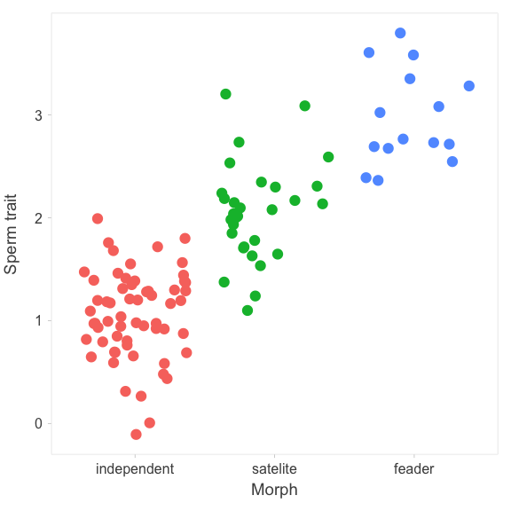

```r
  set.seed(1)
  d = data.table(morph = factor(c( rep('independent', 60),
                                   rep('satelite', 30),
                                   rep('feader', 15)
                                   ),
                                levels = c('independent','satelite','feader')
                                ),
                sperm_trait =  c(rnorm(60, mean = 1, sd = 0.5),
                                 rnorm(30, mean = 2, sd = 0.5),
                                 rnorm(15, mean = 3, sd = 0.5)
                                 )
                )
  #dev.new(width = 3.5, height = 3.5)
  ggplot(d, aes(x = morph, y = sperm_trait, col = morph)) +
    geom_jitter() + theme_MB +  theme(legend.position="none") + xlab('Morph') + ylab('Sperm trait')
```

If, nonetheless, the three morphs differ in the sperm traits, we expect ‘feaders’ sperm to be optimized for speed and to differ the most from the sperm of ‘independents’, while we expect ‘satelites’ sperm to be intermediate between the two. Specifically, we predict that ‘feaders’ have sperm with the longest midpeace and tail and have sperm that is quickest of the three morphs. Consequently, as a part of exploratory analyses, we predict the coefficient of variation in the sperm morphometry and velocity to be the smallest in ‘feaders’. Such optimization shall increase ‘feaders’ chances of inseminating a female despite ‘feaders’ rarity - less than 1% of males (Jukema and Piersma 2006; Jaatinen, Lehikoinen, and Lank 2010) - and despite ‘feaders’ likely have only sporadic chances to copulate. Note that likelihood of copulation for ‘independents’ and ‘satelites’ is driven by the amount of time an individual spends on the lek (Vervoort and Kempenaers 2019) and hence these two morphs may not differ in the sperm characteristics.

**Figure 1** | Predicted relationship between morph type and sperm trait (midpeace, tail, velocity)

### Methods

#### Sperm samples

MB collected sperm of 86 males (51 ‘independents’, 20 ‘satelites’, 15 ‘feaders’) from the Simon Fraser University colony using abdominal massage and cloaca lavage (e.g. Knief et al. (2017); see the [specific protocol](https://raw.githack.com/MartinBulla/ruff_sperm/main/R/protocol_sperm.html); **ADD VIDEOs**). The colony was founded with 110 ruffs hatched from wild eggs collected in Finland in 1985, 1989 and 1990 plus two ‘faeder’ males from the Netherlands in 2006 (Lank et al. 1995, 2013).

Collected sperm samples were and will be pipetted from the cloaca and diluted with 10 - 20 μl of Phosphate buffered saline solution (PBS; Sigma, P-4417). The Vancouver samples were then fixed in 100 μl of ~5% formalin solution. Upon inspecting these samples we found out that ruff sperm has extremely long tails that easily break off or curl up when the sperm dies; this hinders sperm measurements. Thus, during 2021 sampling we plan to prepare the sperm slides on the spot (i.e. without storing the sperm in ~5% formalin solution). The sperm (~0.5–3 μl) will be immediately diluted in a preheated (40°C) Dulbecco’s Modified Eagle’s Medium (Advanced D-MEM, Invitrogen, USA). For the velocity measurement an aliquot will be pipetted onto a standard 20μm two-chamber count slide (Leja, The Netherlands) placed on a heating table kept at 40 °C. For the morphology measurements, an aliquot will be pipetted on microscope slide and the rest of the sperm sample will be fixed in 100μl ~5% formalin solution.

#### Sperm morphometry

For each sample, we will photograph 10 intact normal-looking spermatozoa, less if 10 is not available, with a 12 megapixel (4250 × 2838) digital camera (‘Zeiss Axiocam 512 color’ with pixel size of 3.1μm × 3.1μm). For each sperm, we will measure head (including the acrosome), midpiece and tail length to the nearest 0.1μm using open sources software [ImageJ](https://imagej.nih.gov/ij/). We will calculate total sperm length as the sum of three measurements, and flagellum length as the sum of midpiece and tail length. To minimize observer error, all measurements will be taken by one person (KT).

Note that all measured sperm and features will be numbered, stored and visible within the measured picture and referenced in the database (see [protocol](https://www.dropbox.com/s/ouqfqih4gzx6rq5/Protocol_imageJ_sperm_measuring_manual.docx?dl=0) and [database](https://www.dropbox.com/s/9uk7bcxmd4o1prx/ruff_sperm_morphology.xlsx?dl=0)), which facilitates transparency and, if later needed, allows re-measurement of the same sperm by the same or different person for a possible calculation of repeatability. Also, it allows to measure additional sperm if 10 sperm per male proof too few to calculate coefficient of variation. **PERHASP WE SHALL A PRIORY DECIDE HOW WE DRAW THE LINE HERE**.

We will also compute coefficients of variation (CV = [SD/mean]) both within males and between males of each morph, and adjust them to correct for variation in sample size (CVadj = [1 + 1/(4n)]*CV; (Sokal and Rohlf 1981)).

#### Analysis plan

Sample sizes will reflect the maximum available data. No data selection will be done conditional on the outcome of statistical tests. We will measure the sperm traits and analyse the data on sperm traits blind to the males’ morph. We report all results, all data exclusions, all manipulations and all measures in the study.

#### Statistical analyses

All analyses will be in R (R-Core-Team 2020) using lmer() and glmer() functions of the lme4 package to fit linear and generalized linear mixed-effects models, and the pedigreemm package for fitting the pedigree structure as a random effect. We will estimate the variance explained by the fixed effects of our mixed-effects models as marginal R2-values, using the r.squaredGLMM() function of the MuMIn package (v1.15.6).Model fit was visually validated (by qq-plots of residuals and plots of residuals against fitted values).

We fitted linear mixed-effects models with each sperm trait (head, midpiece and flagellum length, velocity) as dependent variable, the male morph (three-level factor) as explanatory variable and the pedigree structure as a random effect. If we obtain multiple measurements per male, we will also fit male identity as a random effect, unless such inclusion of this variable impairs model convergence.

To investigate whether sperm morphology explains variation in sperm velocity, we will first fit a linear mixed-effects model with velocity as dependent variable, and head, midpiece and flagellum length, as well as their squared terms (after mean-centring) and all two-way interactions between the three linear terms, as explanatory variables while controlling for pedigree structure (fitted as a random effect). In case, some of the sperm traits substantially correlated (Pearson’s r>0.6), we will use only one of the correlated variables.

SHALL WE DO THIS? To evaluate multicollinearity between all main effect predictors, we will estimate their variance inflation factor using the corvif() function (Zuur, Ieno, and Elphick 2009) in R. A general guideline is that a variance inflation factor larger than 5 or 10 is large, indicating that the model has problems estimating the coefficient. However, this in general does not degrade the quality of predictions. If the VIF is larger than 1/(1-R2), where R2 is the Multiple R-squared of the regression, then that predictor is more related to the other predictors than it is to the response. Thus, if VIF is larger than 5 we can use the model for predictions

#### References

Ala-Honkola, O., D. J. Hosken, M. K. Manier, S. Lupold, E. M. Droge-Young, K. S. Berben, W. F. Collins, J. M. Belote, and S. Pitnick. 2013. “Inbreeding Reveals Mode of Past Selection on Male Reproductive Characters in Drosophila Melanogaster.” *Ecol Evol* 3 (7): 2089–2102. https://doi.org/10.1002/ece3.625.

Cramer, E. R., M. Alund, S. E. McFarlane, A. Johnsen, and A. Qvarnstrom. 2016. “Females Discriminate Against Heterospecific Sperm in a Natural Hybrid Zone.” *Evolution*. https://doi.org/10.1111/evo.12986.

Gomendio, M., J. Cassinello, and E. R. Roldan. 2000. “A Comparative Study of Ejaculate Traits in Three Endangered Ungulates with Different Levels of Inbreeding: Fluctuating Asymmetry as an Indicator of Reproductive and Genetic Stress.” *Proc Biol Sci* 267 (1446): 875–82. https://doi.org/10.1098/rspb.2000.1084.

Heber, S., A. Varsani, S. Kuhn, A. Girg, B. Kempenaers, and J. Briskie. 2013. “The Genetic Rescue of Two Bottlenecked South Island Robin Populations Using Translocations of Inbred Donors.” *Proc Biol Sci* 280 (1752): 20122228. https://doi.org/10.1098/rspb.2012.2228.

Jaatinen, Kim, Aleksi Lehikoinen, and David B. Lank. 2010. “Female-Biased Sex Ratios and the Proportion of Cryptic Male Morphs of Migrant Juvenile Ruffs (Philomachus Pugnax) in Finland.” *Ornis Fennica* 87: 25–134.

Jukema, Joop, and Theunis Piersma. 2006. “Permanent Female Mimics in a Lekking Shorebird.” *Biology Letters* 2 (2): 161–64. https://doi.org/10.1098/rsbl.2005.0416.

Knief, Ulrich, Wolfgang Forstmeier, Yifan Pei, Malika Ihle, Daiping Wang, Katrin Martin, Pavlína Opatová, et al. 2017. “A Sex-Chromosome Inversion Causes Strong Overdominance for Sperm Traits That Affect Siring Success.” *Nature Ecology & Evolution* 1 (8): 1177–84. https://doi.org/10.1038/s41559-017-0236-1.

Kupper, C., M. Stocks, J. E. Risse, N. Dos Remedios, L. L. Farrell, S. B. McRae, T. C. Morgan, et al. 2015. “A Supergene Determines Highly Divergent Male Reproductive Morphs in the Ruff.” *Nat Genet*. https://doi.org/10.1038/ng.3443.

Lamichhaney, S., G. Fan, F. Widemo, U. Gunnarsson, D. S. Thalmann, M. P. Hoeppner, S. Kerje, et al. 2015. “Structural Genomic Changes Underlie Alternative Reproductive Strategies in the Ruff (Philomachus Pugnax).” *Nat Genet*. https://doi.org/10.1038/ng.3430.

Lank, David B., Lindsay L. Farrell, Terry Burke, Theunis Piersma, and Susan B. McRae. 2013. “A Dominant Allele Controls Development into Female Mimic Male and Diminutive Female Ruffs.” *Biology Letters* 9 (6). https://doi.org/10.1098/rsbl.2013.0653.

Lank, David B., Constance M. Smith, Olivier Hanotte, Terry Burke, and Fred Cooke. 1995. “Genetic Polymorphism for Alternative Mating Behaviour in Lekking Male Ruff Philomachus Pugnax.” *Nature* 378 (6552): 59–62. https://doi.org/10.1038/378059a0.

Laskemoen, T., O. Kleven, F. FossÃy, R. J. Robertson, G. Rudolfsen, and J. T. Lifjeld. 2010. “Sperm Quantity and Quality Effects on Fertilization Success in a Highly Promiscuous Passerine, the Tree Swallow Tachycineta Bicolor.” *Behavioral Ecology and Sociobiology*, 1–11. http://www.scopus.com/inward/record.url?eid=2-s2.0-77951236330&partnerID=40&md5=4cbc6dbbaec0e670e386b9274a5dcf70.

Lierz, M., M. Reinschmidt, H. Muller, M. Wink, and D. Neumann. 2013. “A Novel Method for Semen Collection and Artificial Insemination in Large Parrots (Psittaciformes).” *Sci Rep* 3: 2066. https://doi.org/10.1038/srep02066.

Opatová, P., M. Ihle, J. Albrechtová, O. Tomášek, B. Kempenaers, W. Forstmeier, and T. Albrecht. 2016. “Inbreeding Depression of Sperm Traits in the Zebra Finch Taeniopygia Guttata.” *Ecol Evol* 6 (1): 295–304. https://doi.org/10.1002/ece3.1868.

R-Core-Team. 2020. “R: A Language and Environment for Statistical Computing - Version 4.0.2.” Vienna (Austria): R Foundation for Statistical Computing. http://www.R-project.org/.

Sokal, R., and F. Rohlf. 1981. *Biometry: The Principles and Practice of Statisticsin Biological Research (2nd Ed.).* New York, NY: W. H. Freeman and Co.

Stoffel, Martin A., Shinichi Nakagawa, Holger Schielzeth, and Sarah Goslee. 2017. “rptR: Repeatability Estimation and Variance Decomposition by Generalized Linear Mixed‐effects Models.” *Methods in Ecology and Evolution* 8 (11): 1639–44. https://doi.org/10.1111/2041-210x.12797.

vanRhijn, Johan G. 1991. *The Ruff*. T. & A.D. Poyser, London.

Vervoort, Raf, and Bart Kempenaers. 2019. “Variation in Lek Attendance and Copulation Success of Independent and Satellite Male Ruffs Calidris Pugnax.” *Ardea* 107. https://doi.org/10.5253/arde.v107i3.a9.

Widemo, F. 1998. “Alternative Reproductive Strategies in the Ruff, Philomachus Pugnax: A Mixed ESS?” *Animal Behavior* 56: 329–36. https://doi.org/https://doi.org/10.1006/anbe.1998.0792.

Zuur, Alain F., Elena N. Ieno, and Chris S. Elphick. 2009. “A Protocol for Data Exploration to Avoid Common Statistical Problems.” *Methods in Ecology and Evolution* 1 (1): 3–14. https://doi.org/10.1111/j.2041-210X.2009.00001.x.